# What Fictional Machine and Human Characters Do With Machine Vision Technologies

2022-01-25

# 1 Introduction

This presentation explores the cultural imaginaries of machine vision technologies as they are portrayed in contemporary science fiction, digital art and videogames. How are the relationships between humans and machines imagined in fictional situations and aesthetic contexts where machine vision technologies occur? Our goal is to use a large-scale analysis of fictional and artistic depictions of machine vision to to understand how the distributed agency of human-technical assemblages is imagined in our global cultural record.

We define machine vision as the registration, analysis and generation of visual data by machines (Rettberg et al. 2019), and include technologies such as facial recognition, optical implants, drones, surveillance cameras and holograms in this. The project team has selected 500 creative works, primarily games, novels, movies, TV shows and artworks, in which machine vision technologies are either described/shown or actually used in the artwork. We have entered structured interpretations of each work in the [Machine Vision in Art, Games and Narratives Database](http://machine-vision.no/knowledgebase).

The dataset includes data describing 77 games, 190 artworks and 233 narratives (in total 500 Creative Works) where machine vision technologies play an important role. This includes Creative Works produced between 1891 and 2021, but with a heavy emphasis on recent works. Only 20% are from 2010 or earlier. 80% of the Works are from 2011-2021, and just over half from 2016-2021. The Creative Works are from 59 different countries, with 78,6% from North America and Europe, and 21,4% from other parts of the world.

This paper asks how fictional characters interactions with machine vision technologies are portrayed.

# 2 Method

We used R and the Tidyverse library to import data about characters and machine vision situations. The characters data consists of a list of characters that interact with machine vision technologies in the 500 works, and each character is described in the traits Species, Gender, Race or Ethnicity, Age and Sexuality. We defined subsets consisting of all the human characters and all the robots, where robots include all kinds of software or hardware robots, cyborgs and AIs.

## 2.1 What kinds of characters interact with machine vision?

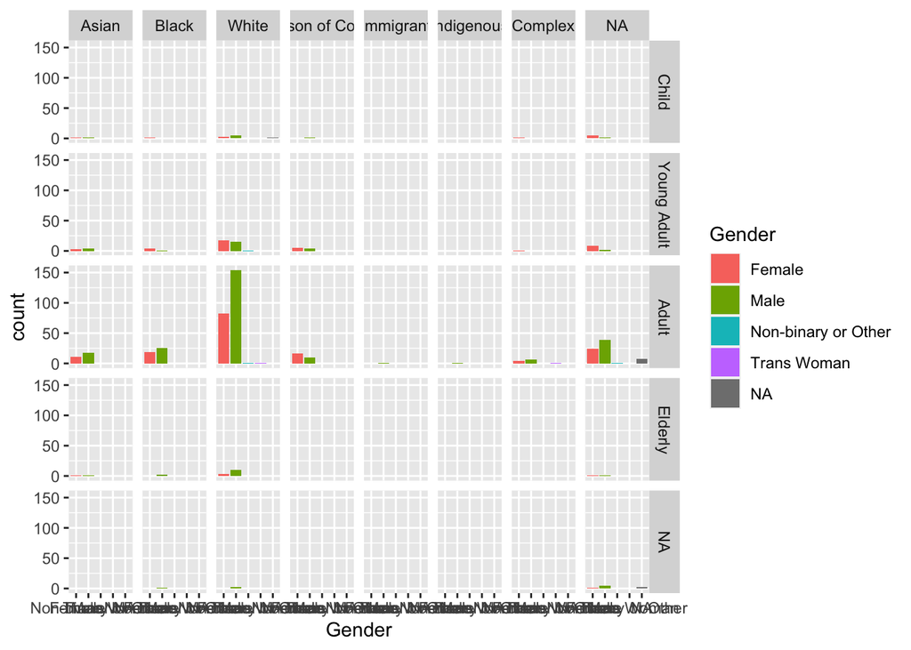

```r
Characters %>%
        filter(IsGroup == FALSE & IsCustomizable == FALSE) %>%
        filter(Species == "Human") %>%
        na_if("Unknown") %>%
        ggplot() +
        geom_bar(mapping = aes(x = Gender, fill = Gender)) +
        facet_grid(Age ~ RaceOrEthnicity)
```

Fictional species include superheros and gods like [Thor](https://machine-vision.no/character/thor) and [Loki](https://machine-vision.no/character/loki) as well as monsters, [ghosts](https://machine-vision.no/character/ghost-breathe) () and various imagined alien species like [Spock](https://machine-vision.no/character/spock) or [Doctor Who](https://machine-vision.no/character/11th-doctor).

We used separate tags for “Machine” and “Cyborg” species because we were interested in the agency of humans in comparison to non-humans, and the cyborg seemed a potentially interesting hybrid categori. We tagged robots and androids, as well as AI systems, as the “Machine” species, and defined “Cyborg” as “A being with both organic and mechanical/machinic body parts.”

## 2.2 Human Sexuality

We logged characters as heterosexual or homosexual if they were mentioned as attracted to or in a sexual or romantic relationship with a character of the opposite or same gender. If both genders, we logged them as bisexual. Sometimes we may not be aware of all presentations of the character [e.g. Dr Who, shuri, characters in franchises – might not have read all – so perhaps they have a same-sex relationship in season X and so really aren’t exclusively heterosexual.

We have not logged the most important characters in the stories overall, but only characters who are directly involved with machine vision technologies. So it is possible that gay and queer characters are more visible in the works as a whole, but queer characters are less likely to be presented as engaging with machine vision technology. Unfortunately we don’t have data to prove or disprove this.

# 3 Robot Sexuality

You may be surprised to find machine characters - robots and AIs, mostly - have sexuality at all. As you can see below, the vast majority of machine and cyborg characters *don’t* have any explicit sexuality.

gender is usually assigned (how are demographics in comparison to western countries?) but sexuality is far less frequently made explicit. When sexuality is explicit, heterosexuality is heavily overrepresented (check).

Far fewer characters are explicitly shown as homosexual or bi-sexual than would be expected based on demographics in Western countries. Only 10 characters are tagged as homosexual. All are entered by Jill…which suggests a methodological issue where other people haven’t entered sexuality? Or perhaps there just aren’t homosexual characters in games and art? A few of the seven bi-sexual characters are entered by others. Lower visibility of queer characters – this is typical and I can cite something about it. Also research team may be defaulting to straight, and there are a lot of Unknown/not applicable.

Compare gendering of machine characters to gendering of voice assistants etc. (Cite Lai-Tze Fan if her book Unseen Hands is out or something else she has done)

Let’s make a new table called “Robots” that just has the robots and cyborgs and AIs - the characters that are tagged as “Machine” or “Cyborg”.

```r
Robots
```

| Character | Species | Gender | Sexuality | RaceOrEthnicity | Age |
| --- | --- | --- | --- | --- | --- |
| Emily | Machine | Female | Heterosexual | White | Adult |
| A2 | Machine | Female | NA | White | Adult |
| Unnamed battlebot | Machine | NA | NA | NA | Adult |
| Avina | Machine | Female | NA | NA | Adult |
| Robot doll (Squid Game) | Machine | Female | NA | NA | Child |
| Klara | Machine | Female | NA | NA | Young Adult |
| Paladin | Cyborg | Trans Woman | Heterosexual | NA | Adult |
| Steel Brother | Machine | Male | NA | NA | Adult |
| Johnny Silverhand | Machine | Male | Heterosexual | White | Adult |
| Alt Cunningham | Machine | Female | Heterosexual | White | Adult |

[output cut: 91 more lines]

```r
#Use base R to make a quick table:
table(Robots$Species, Robots$Sexuality)
```

```
##
##             Homosexual Heterosexual Bi-sexual Other Unknown
##   Animal             0            0         0     0       0
##   Cyborg             1            5         0     0       0
##   Fictional          0            0         0     0       0
##   Human              0            0         0     0       0
##   Machine            0           12         0     0       0
##   Unknown            0            0         0     0       0
```

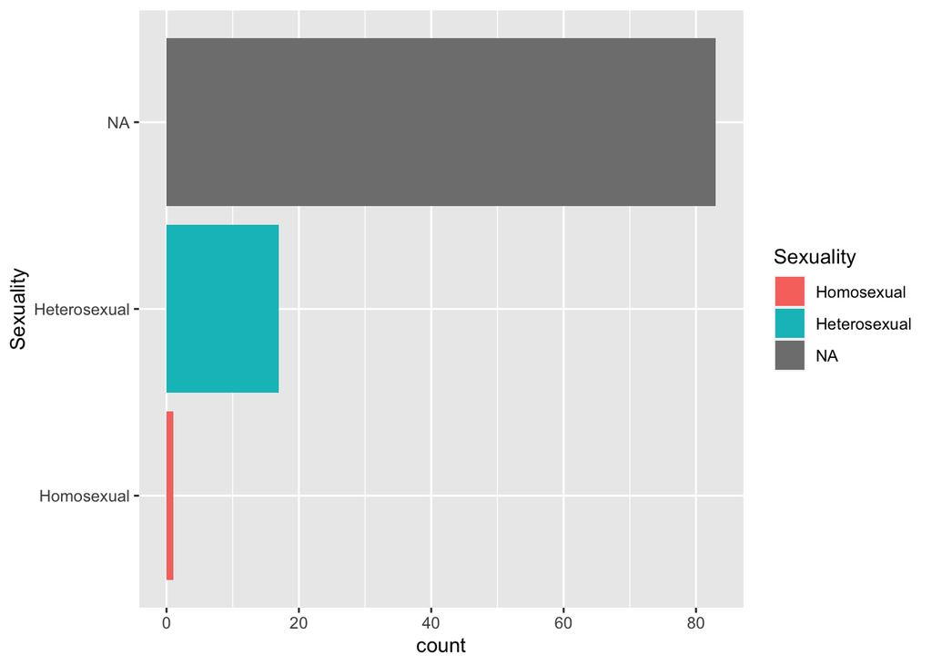

```r
Robots %>%
        ggplot() +
        geom_bar(aes(y=Sexuality, fill=Sexuality))
```

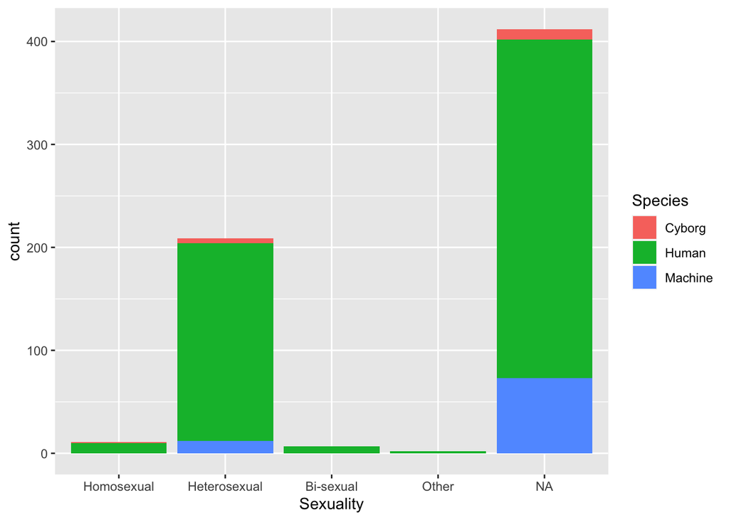

```r
Characters %>%
        filter(IsGroup == FALSE & IsCustomizable == FALSE) %>%
        filter(Species == "Human" | Species == "Machine" | Species == "Cyborg") %>%
        select(Character, Species, Gender, Sexuality) %>%
        na_if("Unknown") %>%
        #filter(is.na(Sexuality)) %>%
        group_by(Species) %>%

        ggplot() +
        geom_bar(aes(x=Sexuality, fill = Species))+
        facet_grid(space="free_y")
```

Maybe a table would be a better way of representing this data, so we can see which machine characters are portrayed as having a sexual preference.

```r
Characters %>%
        filter(IsGroup == FALSE & IsCustomizable == FALSE) %>%
        select(Character, Species, Gender, Sexuality) %>%
        na_if("Unknown") %>%
        filter(Species == "Machine" | Species =="Cyborg") %>%
        group_by(Species, Sexuality) %>%
        filter(!is.na(Sexuality))
```

| Character | Species | Gender | Sexuality |
| --- | --- | --- | --- |
| Emily | Machine | Female | Heterosexual |
| Paladin | Cyborg | Trans Woman | Heterosexual |
| Johnny Silverhand | Machine | Male | Heterosexual |
| Alt Cunningham | Machine | Female | Heterosexual |
| Amber Rose 348 | Machine | Male | Heterosexual |
| Adam Newman | Machine | Male | Heterosexual |
| Krissana Khongtip | Cyborg | Female | Homosexual |
| Chitti the robot | Machine | Male | Heterosexual |
| Nila the robot | Machine | Female | Heterosexual |
| Alita | Cyborg | Female | Heterosexual |

[output cut: 8 more lines]

Emily at the top of that list is the narrator of the novel [*Emily Eternal*](https://machine-vision.no/creative-work/emily-eternal) by M.G. Wheaton (2019). She is an artificial intelligence designed by MIT researchers to feel empathy with humans, and she is experienced as physically present by humans who wear an interface chip that allows Emily to interface directly with their brains. In the first pages of the novel this is explained to the reader:

> The chip allows me to manipulate Regina’s senses of sight, smell, touch, and hearing. Her eyes tell her brain there’s a Caucasian woman in her early thirties with brown hair, blue-green eyes, and a kind face sitting opposite her. Her ears tell her my voice has a mid-range pitch, not too low, not too high, with a slight New Englander’s accent. Her nose tells her I use mostly fragrance-free soap, a kiwi-infused shampoo, no perfume, but a baby powder–scented antiperspirant. When I touch her hand or even embrace her, I come off as warm, upright but not rigid, and a good hugger. In return, the chip gives me unlimited access to her brain, including thoughts, memories, learned behaviors, hopes and dreams, worst fears, and all things in between. Utilizing bioalgorithms, I’m able to create a comprehensive neural map of an individual’s mind that can then be used in a therapeutic context to help patients with their issues, large or small. (Wheaton, M. G. 2019. *Emily Eternal* (pp. 5-6). Grand Central Publishing. Kindle Edition.)

This is surprisingly typical: machine characters tend to be described as very human-like, and one of the ways they are anthropomorphised is by being assigned explicit gender, sexuality and race. The above excerpt makes it easy to tag Emily for our dataset: her species (an AI, thus a “Machine”), race, gender and age are all explicitly described. Her sexuality is very clear later on in the novel: she is in love with Jason:

> So yeah, he’s my crush. Not entirely sure when it started (yeah, right—Emily’s Crushing On Jason Protocol went online precisely nine weeks, four days, three hours, and fifty minutes ago…he was wearing a green cardigan), but it took a few hours of systems analysis to make certain it had developed naturally as part of my evolving socialization rather than another mental mouse maze my colleagues had dropped me into. That my emotional responses to it are not only real but ever-changing, as well as its possible-to-even-likely transience, is why I’ve kept it cloaked from my team. (p. 23).

```r
Characters %>%
        filter(Character == "Emily")
```

| CharacterID | Character | Species | Gender | RaceOrEthnicity | Age | Sexuality | IsGroup | IsCustomizable |
| --- | --- | --- | --- | --- | --- | --- | --- | --- |
| 3251 | Emily | Machine | Female | White | Adult | Heterosexual | FALSE | FALSE |

## 3.1 Why is there only one gay robot?

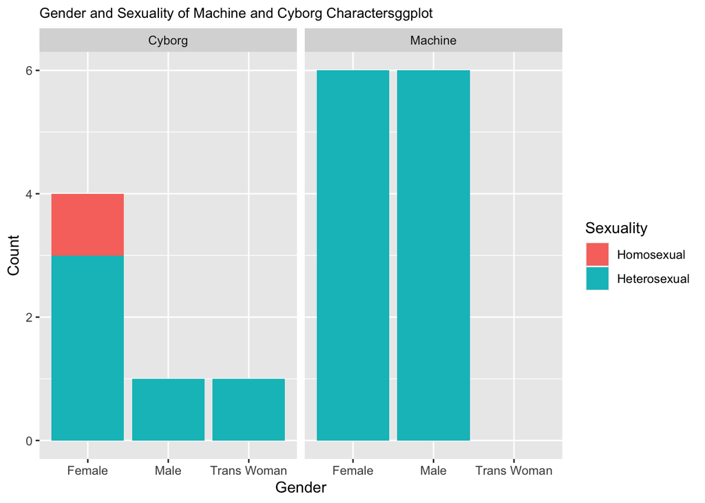

```r
Characters %>%
        filter(IsGroup == FALSE & IsCustomizable == FALSE) %>%
        select(Character, Species, Gender, Sexuality) %>%
        na_if("Unknown") %>%
        filter(Species == "Machine" | Species =="Cyborg") %>%
        group_by(Species, Sexuality) %>%
        filter(!is.na(Sexuality)) %>%
        ggplot() +
        geom_bar(aes(x=Gender, fill=Sexuality)) +
        facet_grid(. ~ Species) +
        scale_size_area(max_size = 7) +
        labs(title = "Gender and Sexuality of Machine and Cyborg Charactersggplot",
             y = "Count",
             x = "Gender") +
theme(plot.title = element_text(size = 10))
```

### 3.1.1 Gender and sexuality

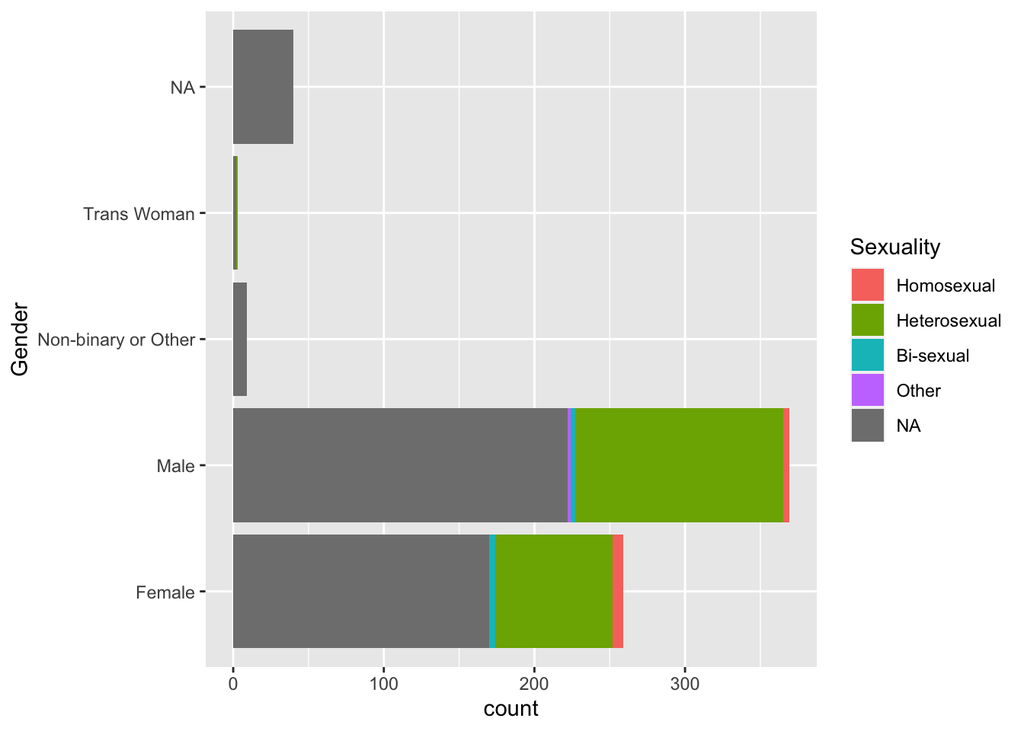

```r
Characters %>%
        filter(IsGroup == FALSE & IsCustomizable == FALSE) %>%
        na_if("Unknown") %>%
        ggplot() +
        geom_bar(na.rm = TRUE, mapping = aes(y = Gender, fill = Sexuality))
```

# 4 What do characters *do* with machine vision?

There are some notable differences in the verbs associated with different genders in our dataset.

## 4.1 Active verbs

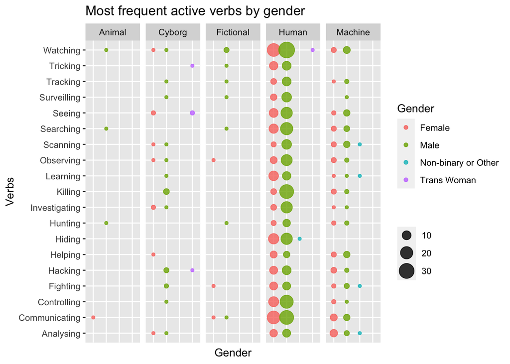

```r
# Using the Tidyverse library the following code takes Character_verbs and then
# does the following:
# 1. Adds a column called VerbCount that gives a count of each verb
# 2. Arranges the dataframe in decreasing order by VerbCount
# 3. Filters the dataframe to only include rows where the VerbCount is more
# than 20
# 4. Filters the dataframe to only include rows where Gender isn’t unknown.
# 5. Filters the dataframe to only include rows where the string “ing” is
# detected in the Verb variable.
# 6. Makes a plot where the visible objects are based on the Verb and Gender
# columns.
# 7. Uses geom_count to plot this - this is a geom that is good for discrete or
# categorical values (like text rather than numbers) that shows a bigger or
# smaller point (circle) depending on how many co-occurences each x and y value
# have.
# 8. Set the max size of the points to 7.
# 9. Adds labels to the diagram.

Character_verbs %>%
  add_count(Verb, name = "VerbCount") %>%
  arrange(desc(VerbCount)) %>%
  filter(VerbCount>20) %>%
  filter(Gender != "Unknown") %>%
  filter(str_detect(Verb, "ing")) %>%
  ggplot(aes(y = Verb, x = Gender)) +
  geom_count(aes(colour = Gender), alpha = 0.8) +
  facet_grid(. ~ Species) +
  scale_size_area(max_size = 7) +
  labs(title = "Most frequent active verbs by gender",
       y = "Verbs",
       x = "Gender",
       size = "") +
   theme(axis.ticks.x = element_blank(),
        axis.text.x = element_blank())
```

## 4.2 Passive Verbs

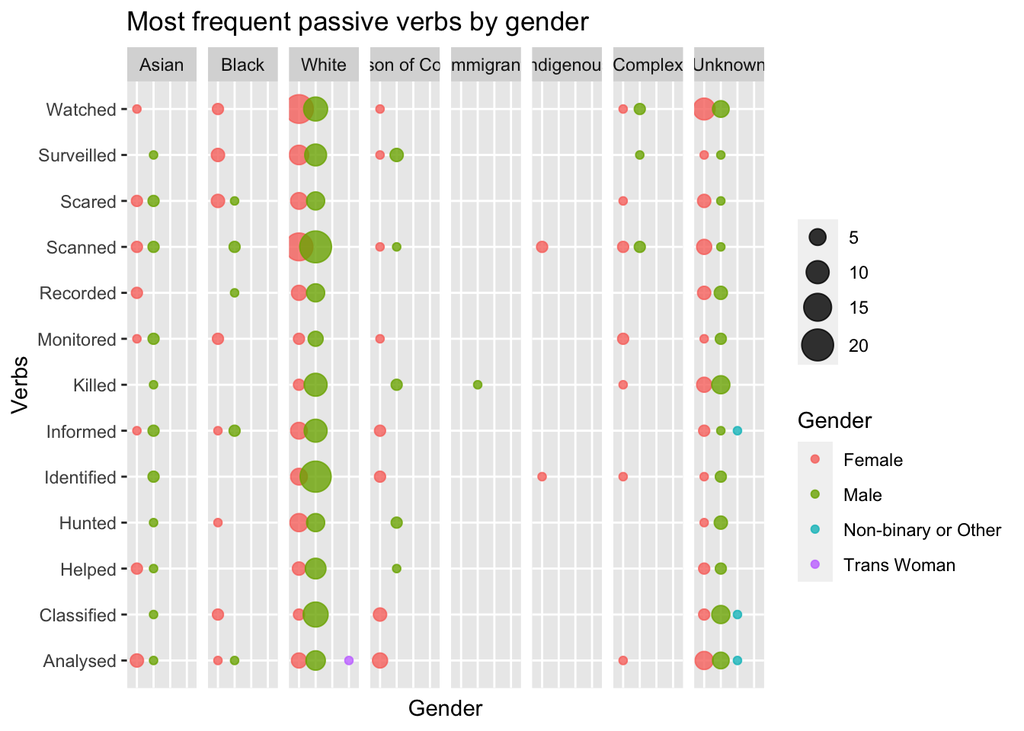

```r
Character_verbs %>%
  add_count(Verb, name = "VerbCount") %>%
  arrange(desc(VerbCount)) %>%
  filter(VerbCount>20) %>%
  filter(Gender != "Unknown") %>%
  filter(str_detect(Verb, "ed")) %>%
  ggplot(aes(y = Verb, x = Gender)) +
  geom_count(aes(colour = Gender), alpha = 0.8) +
  facet_grid(. ~ RaceOrEthnicity) +
  scale_size_area(max_size = 7) +
  labs(title = "Most frequent passive verbs by gender",
       y = "Verbs",
       x = "Gender",
       size = "") +
   theme(axis.ticks.x = element_blank(),
        axis.text.x = element_blank())
```

(the following is from SLSA version) Notably, the male characters are portrayed as having far more active relationships with machine vision technologies than characters of other genders are. This indicates that women are more often portrayed as the object being acted upon by machine vision, while men are more often portrayed as active subjects making use of machine vision to further their own agency. While both men and women in the dataset are often portrayed to be watching, women are more frequently being watched, while men are a lot more likely to be the ones doing the watching rather than being watched. Men are also more likely to be killed by machine vision technologies, and there are more male characters overall in our dataset.